# synapter report

03 September, 2018

# Input

## Files

|  | File name | Number of features |
| --- | --- | --- |
| Identification peptide: | 01_HDMSe_tiny.csv | 4979 |
| Quantitation peptide: | 02_MSe_tiny.csv | 3492 |
| Quantitation Pep3D: | 03_Pep3D_tiny.csv | 8356 |
| Fasta file: | 04_test_database.fasta |  |

## General Parameters

| Parameter name | Value |
| --- | --- |
| Master | FALSE |
| Peptide FDR | 0.01 |
| Protein FPR | 0.01 |
| Peptide Length | 7 |
| Missed cleavages | 0 |
| Isoleucin equals Leucin | FALSE |
| Identification mass tolerance (ppm) | 20 |
| Quantitation mass tolerance (ppm) | 20 |
| Loess span (RT modelling) | 0.05 |
| Filtering unique peptides | TRUE |

## Grid Search Parameters

| Grid parameter | Value |
| --- | --- |
| Mass tolerance (ppm) start | 2 |
| Mass tolerance (ppm) end | 20 |
| Mass tolerance (ppm) by | 2 |
| Retention time stdev start | 0.5 |
| Retention time stdev end | 5 |
| Retention time stdev by | 0.5 |
| Feature proportion | 0.2 |
| Number of features | 0 |
| parameters selection | auto |

# Filtering

## Peptide False Discovery Rate

### Peptide Scores

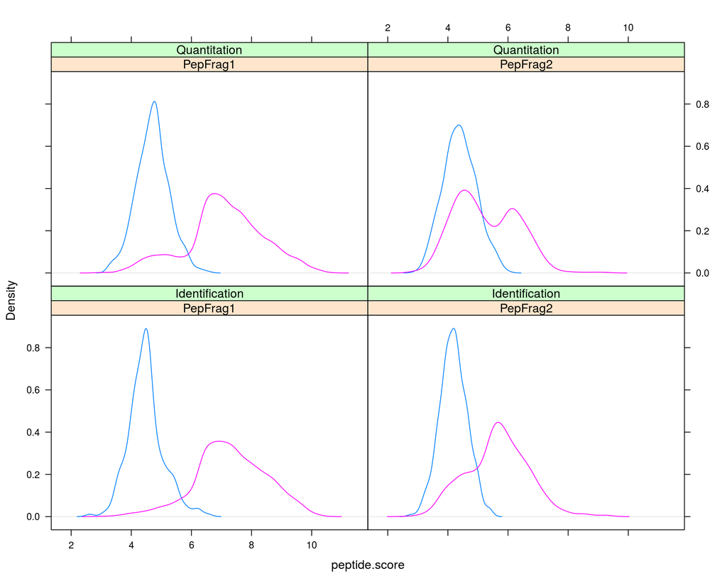

### Peptide Numbers

|  | PepFrag1.Random | PepFrag1.Regular | PepFrag2.Random | PepFrag2.Regular |
| --- | --- | --- | --- | --- |
| ident | 256 | 3522 | 448 | 1393 |
| quant | 496 | 2664 | 500 | 745 |

### Peptide FDR

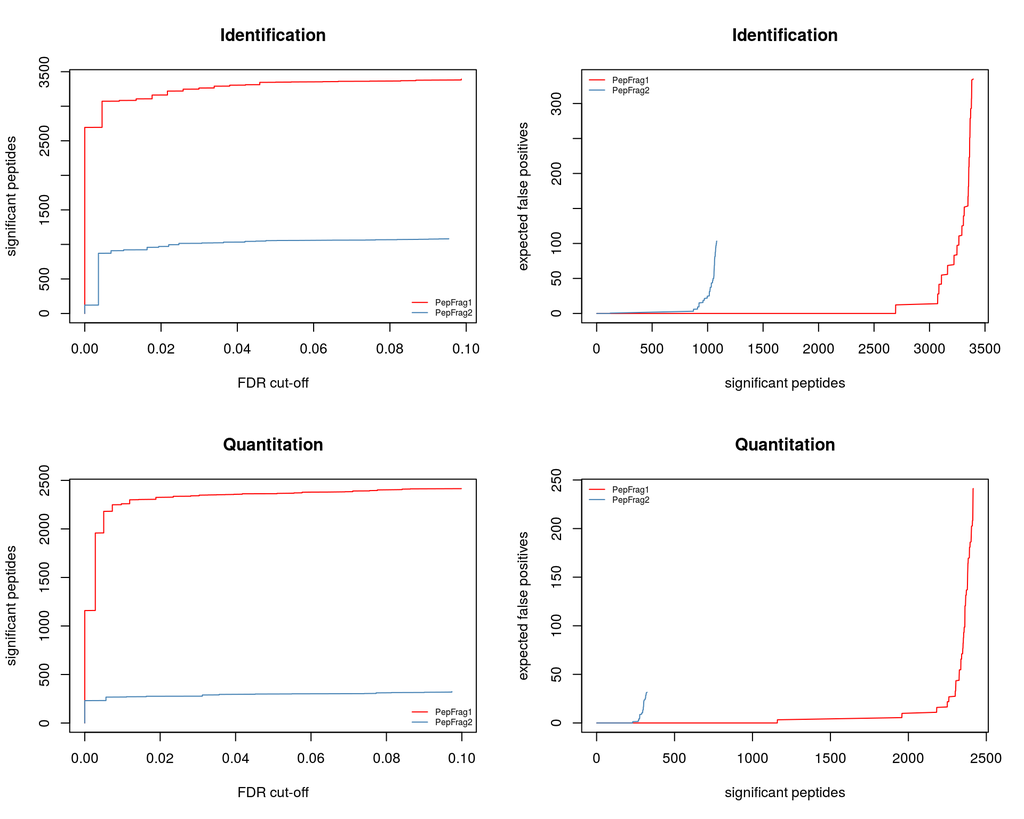

## Mass tolerance

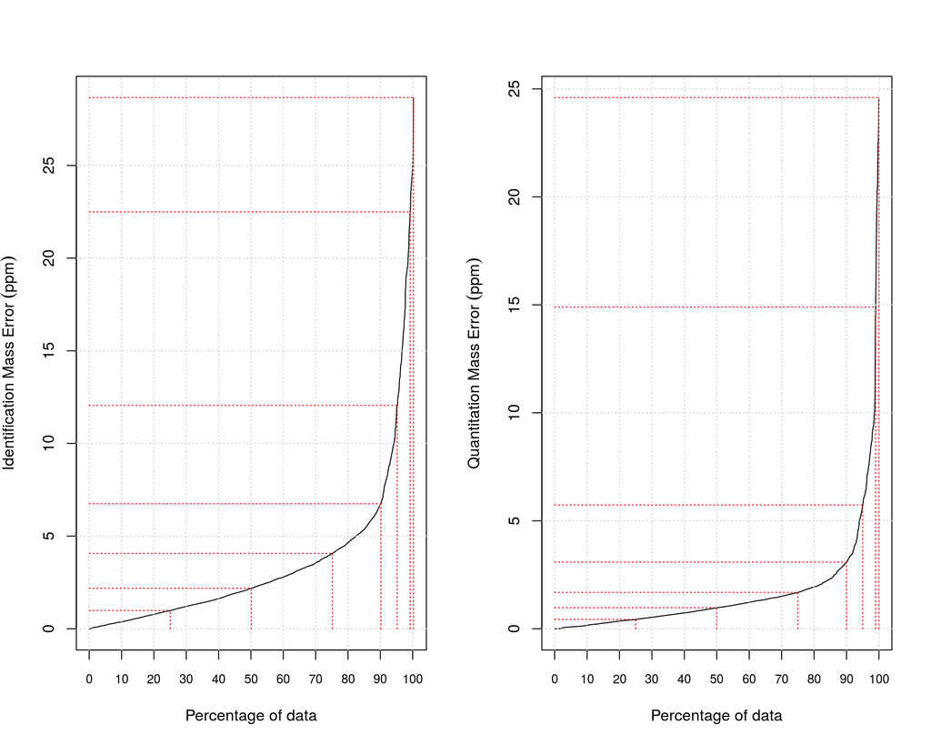

|  | 25% | 50% | 75% | 90% | 91% | 92% | 93% | 94% | 95% | 96% | 97% | 98% | 99% | 100% |
| --- | --- | --- | --- | --- | --- | --- | --- | --- | --- | --- | --- | --- | --- | --- |
| Ident | 0.982 | 2.183 | 4.070 | 6.750 | 7.663 | 8.299 | 9.136 | 9.989 | 12.060 | 13.997 | 16.082 | 19.288 | 22.496 | 28.664 |
| Quant | 0.432 | 0.972 | 1.682 | 3.083 | 3.341 | 3.606 | 3.992 | 5.021 | 5.733 | 6.455 | 7.736 | 9.124 | 14.897 | 24.599 |

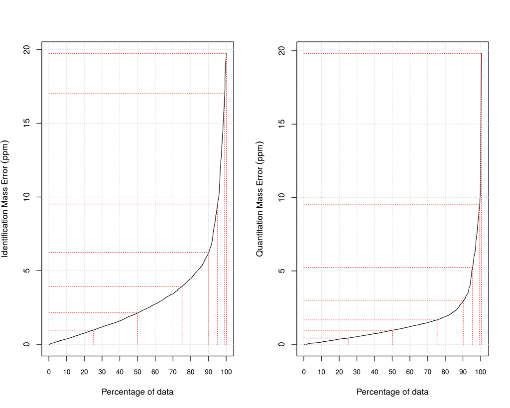

|  | 25% | 50% | 75% | 90% | 91% | 92% | 93% | 94% | 95% | 96% | 97% | 98% | 99% | 100% |
| --- | --- | --- | --- | --- | --- | --- | --- | --- | --- | --- | --- | --- | --- | --- |
| Ident | 0.968 | 2.144 | 3.939 | 6.233 | 6.589 | 7.035 | 7.942 | 8.775 | 9.523 | 10.688 | 12.643 | 14.563 | 17.007 | 19.744 |
| Quant | 0.430 | 0.962 | 1.662 | 3.008 | 3.202 | 3.413 | 3.843 | 4.407 | 5.239 | 6.103 | 7.162 | 8.261 | 9.548 | 19.817 |

# Retention Time Modelling

## Retention Time Model

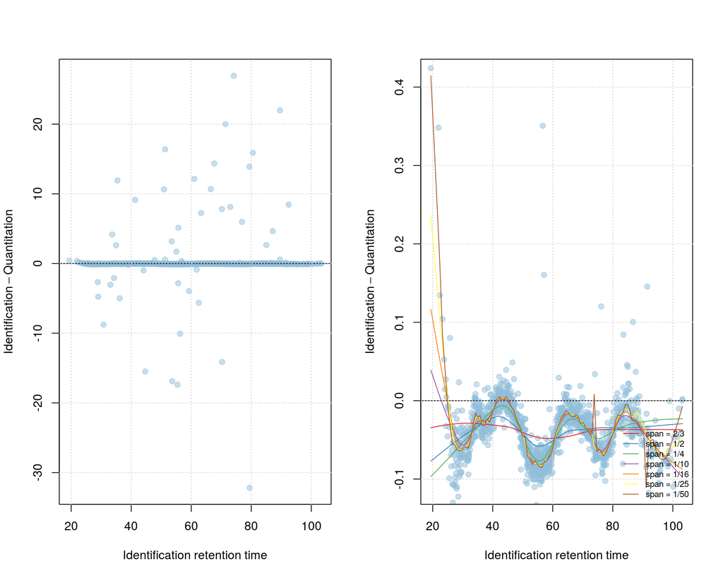

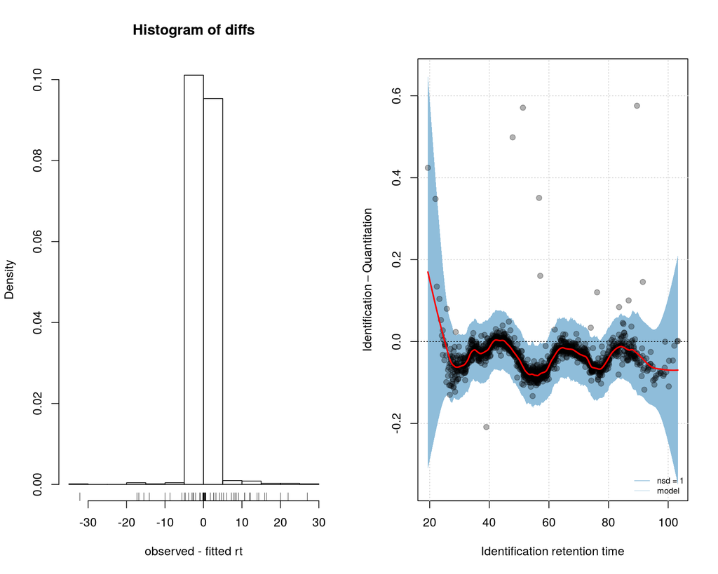

|  | 25% | 50% | 75% | 90% | 91% | 92% | 93% | 94% | 95% | 96% | 97% | 98% | 99% | 100% |
| --- | --- | --- | --- | --- | --- | --- | --- | --- | --- | --- | --- | --- | --- | --- |
| Retention time difference: | 0.003 | 0.008 | 0.016 | 0.029 | 0.031 | 0.034 | 0.04 | 0.047 | 0.057 | 0.072 | 0.463 | 4.161 | 10.703 | 32.14 |

## Feature Space

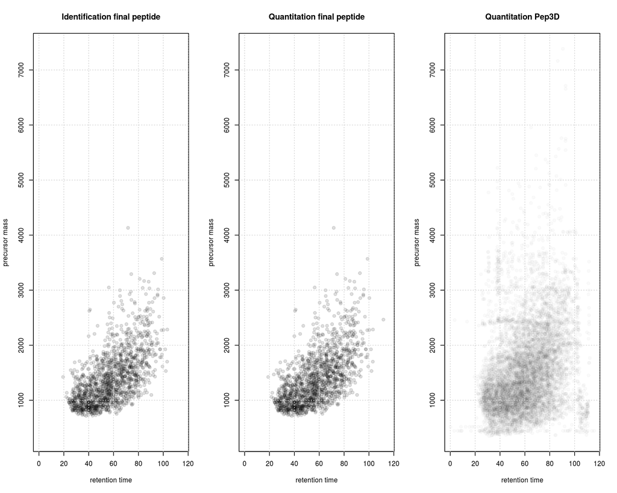

[figure not shown]

Using nsd = 2 and ppm error = 10 as an example.  
Optimal values are selected below.

# Grid Optimisation

Using 20% of the data.

plotGrid(obj, what=“details”)

## Grid Tables

#### total

##### Image

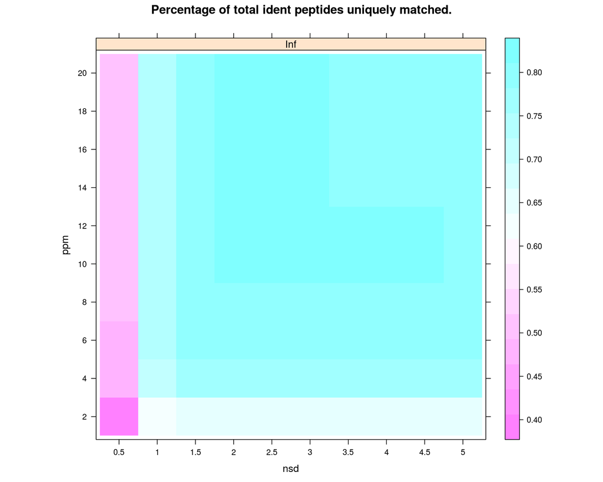

##### Table

|  | 2 | 4 | 6 | 8 | 10 | 12 | 14 | 16 | 18 | 20 |
| --- | --- | --- | --- | --- | --- | --- | --- | --- | --- | --- |
| 0.5 | 0.406 | 0.479 | 0.489 | 0.494 | 0.496 | 0.496 | 0.496 | 0.496 | 0.496 | 0.496 |
| 1 | 0.609 | 0.721 | 0.742 | 0.750 | 0.752 | 0.752 | 0.752 | 0.752 | 0.752 | 0.752 |
| 1.5 | 0.645 | 0.768 | 0.793 | 0.805 | 0.808 | 0.808 | 0.808 | 0.808 | 0.808 | 0.808 |
| 2 | 0.649 | 0.772 | 0.796 | 0.808 | 0.811 | 0.811 | 0.811 | 0.811 | 0.811 | 0.811 |
| 2.5 | 0.649 | 0.772 | 0.796 | 0.808 | 0.811 | 0.811 | 0.811 | 0.811 | 0.811 | 0.811 |
| 3 | 0.649 | 0.772 | 0.796 | 0.808 | 0.811 | 0.811 | 0.811 | 0.811 | 0.811 | 0.811 |
| 3.5 | 0.649 | 0.772 | 0.796 | 0.808 | 0.811 | 0.811 | 0.810 | 0.810 | 0.810 | 0.810 |
| 4 | 0.649 | 0.772 | 0.796 | 0.808 | 0.811 | 0.811 | 0.810 | 0.810 | 0.810 | 0.810 |
| 4.5 | 0.650 | 0.773 | 0.798 | 0.810 | 0.811 | 0.811 | 0.808 | 0.808 | 0.808 | 0.808 |
| 5 | 0.650 | 0.773 | 0.796 | 0.808 | 0.810 | 0.810 | 0.806 | 0.806 | 0.806 | 0.806 |

Best Grid Value total: 0.8111658

| nsd | ppm | imdiff |
| --- | --- | --- |
| 2.0 | 10 | Inf |
| 2.5 | 10 | Inf |
| 3.0 | 10 | Inf |
| 3.5 | 10 | Inf |
| 4.0 | 10 | Inf |
| 4.5 | 10 | Inf |
| 2.0 | 12 | Inf |
| 2.5 | 12 | Inf |
| 3.0 | 12 | Inf |
| 3.5 | 12 | Inf |
| 4.0 | 12 | Inf |
| 4.5 | 12 | Inf |
| 2.0 | 14 | Inf |
| 2.5 | 14 | Inf |
| 3.0 | 14 | Inf |
| 2.0 | 16 | Inf |
| 2.5 | 16 | Inf |
| 3.0 | 16 | Inf |
| 2.0 | 18 | Inf |
| 2.5 | 18 | Inf |
| 3.0 | 18 | Inf |
| 2.0 | 20 | Inf |
| 2.5 | 20 | Inf |
| 3.0 | 20 | Inf |

#### model

##### Image

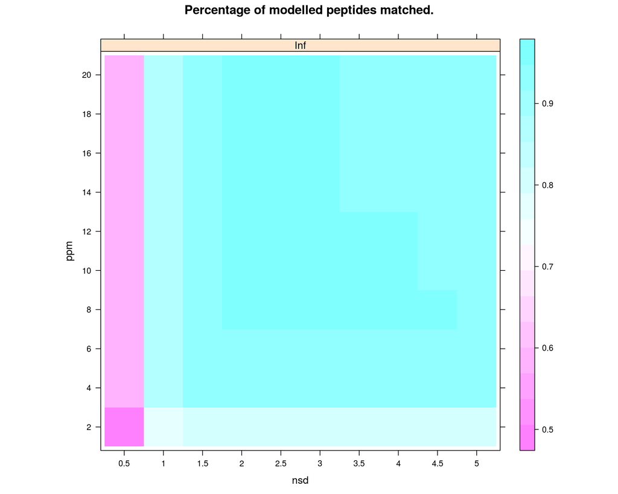

##### Table

|  | 2 | 4 | 6 | 8 | 10 | 12 | 14 | 16 | 18 | 20 |
| --- | --- | --- | --- | --- | --- | --- | --- | --- | --- | --- |
| 0.5 | 0.505 | 0.578 | 0.578 | 0.581 | 0.581 | 0.581 | 0.581 | 0.581 | 0.581 | 0.581 |
| 1 | 0.761 | 0.865 | 0.869 | 0.872 | 0.872 | 0.872 | 0.872 | 0.872 | 0.872 | 0.872 |
| 1.5 | 0.813 | 0.931 | 0.934 | 0.941 | 0.941 | 0.941 | 0.941 | 0.941 | 0.941 | 0.941 |
| 2 | 0.820 | 0.938 | 0.941 | 0.948 | 0.948 | 0.948 | 0.948 | 0.948 | 0.948 | 0.948 |
| 2.5 | 0.820 | 0.938 | 0.941 | 0.948 | 0.948 | 0.948 | 0.948 | 0.948 | 0.948 | 0.948 |
| 3 | 0.820 | 0.938 | 0.941 | 0.948 | 0.948 | 0.948 | 0.948 | 0.948 | 0.948 | 0.948 |
| 3.5 | 0.820 | 0.938 | 0.941 | 0.948 | 0.948 | 0.948 | 0.945 | 0.945 | 0.945 | 0.945 |
| 4 | 0.820 | 0.938 | 0.941 | 0.948 | 0.948 | 0.948 | 0.945 | 0.945 | 0.945 | 0.945 |
| 4.5 | 0.820 | 0.938 | 0.941 | 0.948 | 0.945 | 0.945 | 0.941 | 0.941 | 0.941 | 0.941 |
| 5 | 0.820 | 0.938 | 0.938 | 0.945 | 0.941 | 0.941 | 0.938 | 0.938 | 0.938 | 0.938 |

Best Grid Value model: 0.9480969

| nsd | ppm | imdiff |
| --- | --- | --- |
| 2.0 | 8 | Inf |
| 2.5 | 8 | Inf |
| 3.0 | 8 | Inf |
| 3.5 | 8 | Inf |
| 4.0 | 8 | Inf |
| 4.5 | 8 | Inf |
| 2.0 | 10 | Inf |
| 2.5 | 10 | Inf |
| 3.0 | 10 | Inf |
| 3.5 | 10 | Inf |
| 4.0 | 10 | Inf |
| 2.0 | 12 | Inf |
| 2.5 | 12 | Inf |
| 3.0 | 12 | Inf |
| 3.5 | 12 | Inf |
| 4.0 | 12 | Inf |
| 2.0 | 14 | Inf |
| 2.5 | 14 | Inf |
| 3.0 | 14 | Inf |
| 2.0 | 16 | Inf |
| 2.5 | 16 | Inf |
| 3.0 | 16 | Inf |
| 2.0 | 18 | Inf |
| 2.5 | 18 | Inf |
| 3.0 | 18 | Inf |
| 2.0 | 20 | Inf |
| 2.5 | 20 | Inf |
| 3.0 | 20 | Inf |

#### details

##### Image

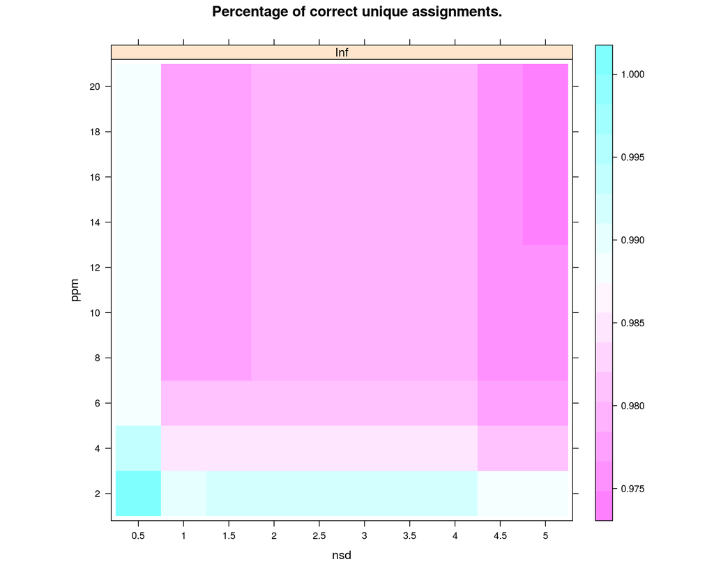

##### Table

|  | 2 | 4 | 6 | 8 | 10 | 12 | 14 | 16 | 18 | 20 |
| --- | --- | --- | --- | --- | --- | --- | --- | --- | --- | --- |
| 0.5 | 1.000 | 0.994 | 0.988 | 0.988 | 0.988 | 0.988 | 0.988 | 0.988 | 0.988 | 0.988 |
| 1 | 0.991 | 0.984 | 0.980 | 0.977 | 0.977 | 0.977 | 0.977 | 0.977 | 0.977 | 0.977 |
| 1.5 | 0.992 | 0.985 | 0.982 | 0.978 | 0.978 | 0.978 | 0.978 | 0.978 | 0.978 | 0.978 |
| 2 | 0.992 | 0.985 | 0.982 | 0.979 | 0.979 | 0.979 | 0.979 | 0.979 | 0.979 | 0.979 |
| 2.5 | 0.992 | 0.985 | 0.982 | 0.979 | 0.979 | 0.979 | 0.979 | 0.979 | 0.979 | 0.979 |
| 3 | 0.992 | 0.985 | 0.982 | 0.979 | 0.979 | 0.979 | 0.979 | 0.979 | 0.979 | 0.979 |
| 3.5 | 0.992 | 0.985 | 0.982 | 0.979 | 0.979 | 0.979 | 0.978 | 0.978 | 0.978 | 0.978 |
| 4 | 0.992 | 0.985 | 0.982 | 0.979 | 0.979 | 0.979 | 0.978 | 0.978 | 0.978 | 0.978 |
| 4.5 | 0.988 | 0.982 | 0.978 | 0.975 | 0.975 | 0.975 | 0.975 | 0.975 | 0.975 | 0.975 |
| 5 | 0.988 | 0.982 | 0.978 | 0.975 | 0.975 | 0.975 | 0.975 | 0.975 | 0.975 | 0.975 |

Best Grid Value details: 1

| nsd | ppm | imdiff |
| --- | --- | --- |
| 0.5 | 2 | Inf |

## Grid Details

| nsd | ppm | -2 | -1 | 0 | 1 | 2 |
| --- | --- | --- | --- | --- | --- | --- |
| 0.5 | 2 | 0 | 0 | 143 | 146 | 0 |
| 0.5 | 4 | 0 | 1 | 121 | 167 | 0 |
| 0.5 | 6 | 0 | 2 | 120 | 167 | 0 |
| 0.5 | 8 | 0 | 2 | 119 | 168 | 0 |
| 0.5 | 10 | 0 | 2 | 119 | 168 | 0 |
| 0.5 | 12 | 0 | 2 | 119 | 168 | 0 |
| 0.5 | 14 | 0 | 2 | 119 | 168 | 0 |
| 0.5 | 16 | 0 | 2 | 119 | 168 | 0 |
| 0.5 | 18 | 0 | 2 | 119 | 168 | 0 |
| 0.5 | 20 | 0 | 2 | 119 | 168 | 0 |
| 1 | 2 | 0 | 2 | 67 | 220 | 0 |
| 1 | 4 | 0 | 4 | 35 | 250 | 0 |
| 1 | 6 | 0 | 5 | 33 | 251 | 0 |
| 1 | 8 | 0 | 6 | 31 | 252 | 0 |
| 1 | 10 | 0 | 6 | 31 | 252 | 0 |
| 1 | 12 | 0 | 6 | 31 | 252 | 0 |
| 1 | 14 | 0 | 6 | 31 | 252 | 0 |
| 1 | 16 | 0 | 6 | 31 | 252 | 0 |
| 1 | 18 | 0 | 6 | 31 | 252 | 0 |
| 1 | 20 | 0 | 6 | 31 | 252 | 0 |
| 1.5 | 2 | 0 | 2 | 52 | 235 | 0 |
| 1.5 | 4 | 0 | 4 | 16 | 269 | 0 |
| 1.5 | 6 | 0 | 5 | 14 | 270 | 0 |
| 1.5 | 8 | 0 | 6 | 11 | 272 | 0 |
| 1.5 | 10 | 0 | 6 | 11 | 272 | 0 |
| 1.5 | 12 | 0 | 6 | 11 | 272 | 0 |
| 1.5 | 14 | 0 | 6 | 11 | 272 | 0 |
| 1.5 | 16 | 0 | 6 | 11 | 272 | 0 |
| 1.5 | 18 | 0 | 6 | 11 | 272 | 0 |
| 1.5 | 20 | 0 | 6 | 11 | 272 | 0 |

[output cut: 70 more lines]

## Best Grid Parameters

Setting best grid parameters using ‘auto’

- Mass tolerance (ppm): 8
- Number of retention time stdev: 2

# EMRT Matching

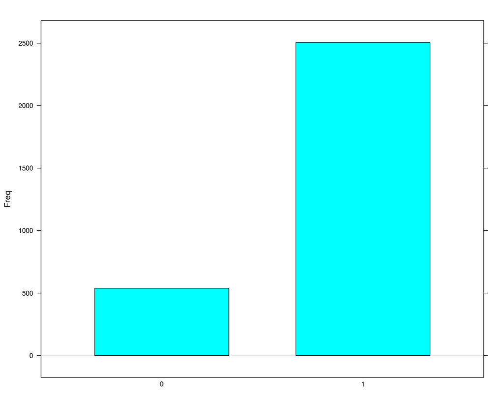

| Number of assigned EMRTs | Freq |
| --- | --- |
| 0 | 539 |
| 1 | 2506 |

# Performance

## Enrichment

| group | values |
| --- | --- |
| (S) Synapter (uniquely matched EMRTs) | 2506 |
| (I) Identification | 3045 |
| (Q) Quantitation | 1840 |
| (S/Q) Enrichment | 36.2% |

## Overlap

|  | Number of peptides |
| --- | --- |
| Q | 433 |
| S | 1097 |
| QS | 1407 |

## Source

|  | Number of peptides with valid counts | Number of `NA` |
| --- | --- | --- |
| rescue | 5 | 29 |
| transfer | 2506 | 505 |

# Exported Files

- Identification Peptides
- Quantitation Peptides
- Merged Peptides
- Matched Peptides
- QuantPeptides.csv
- Grid Details
- Saved R Object (binary)

# Full Analysis Log

- Instance created on Wed Jun 6 23:37:36 2012
- Read identification peptide data [5915,18]
- Read quantitation peptide data [4731,17]
- Read quantitation Pep3D data [8356,10]
- Filtered identification peptide by PepFrag1|2 [5684,18]
- Filtered quantitation peptide by PepFrag1|2 [4492,17]
- Filtered quantitation Pep3D by Function [8356,10]
- Kept unique spectrum ids quantitation Pep3D [8356,10]
- Added identification statistics to quantitation data
- Filtered quantitation Random entries [3492,21]
- Added identification statistics to identification data
- Filtered identification Random entries [4979,22]
- Instance updated to synapter 1.99.0 on Sun Oct 16 16:47:24 2016
- Kept quantitation non duplicated peptide sequences [3327,21]
- Kept identification non duplicated peptide sequences [4852,22]
- Kept identification peptides that match unique protein (0 missed cleavages; I/L treatment: I != L) [3726,22]
- Kept quantitation peptides that match unique protein (0 missed cleavages; I/L treatment: I != L) [2279,21]
- Keeping quant peptides of length >= 7 [2105,21]
- Keeping ident peptides of length >= 7 [3545,22]
- Set peptide score fdr to 0.01
- Filtered quantitation peptide data on pep score with fdr 0.01 [1860,21]
- Filtered identification peptide data on pep score with fdr 0.01 [3097,22]
- Set quantitation ppm error to 20
- Quantitation mass error filtered at 20 ppm [1849,21]
- Set identification ppm error to 20
- Identification mass error filtered at 20 ppm [3045,22]
- Set protein fpr to 0.01
- Filtered identification peptide data using protein fpr 0.01 [3045,22]
- Set protein fpr to 0.01
- Filtered quantitation peptide data using protein fpr 0.01 [1840,21]
- Merged identification and quantitation data [1456,44]
- Set span to 0.05
- Modelled retention time using lowess and span 0.05
- Set nsd to 2
- Set ppm error to 10
- Performed grid search using 20% of identification peptides.
- Set ‘nsd’, ‘ppm error’ and ‘im diff’ to 2, 8 and Inf (best ‘auto’)
- Matched identification peptides and quantitation EMRTs [3045,37]
- Rescue EMRTs [3045,37] (rescue)